# Posterior_Distributions

Jeffrey Hunt

2022-11-08

# Import Libraries

```r
library(markovchain)
library(diagram)
library(DiagrammeR)
library(nleqslv)
library(MHadaptive)
library(expm)
```

## Problem Statment

What is the predicted likelihood of people visiting a given attraction using the Markov Chain Monte Caro (MCMC) method?

## Load Data

```r
data <- read.csv("syndata.csv", header = FALSE)

data <-data.frame(data)

headers = c("Museum", "Concert", "Sports", "Restaurant", "Hike")

data
```

```
##   V1 V2 V3 V4 V5
## 1  1  3  5  3  3
## 2  7  1  4  6  3
## 3  8  2  2  5  4
## 4  5  4  5  3  1
## 5  2  4  1  5  1
```

## Create Table of Conditional Probabilites

```r
# We covert the the original table into a condtional probability Table
  #Example Concert / Museum = 3 / 15 = 0.2000
data_new<-t(apply(data,1, function(x) x/sum(x)))

data_new <- data.frame(data_new)

data_new
```

```
##           V1         V2         V3        V4         V5
## 1 0.06666667 0.20000000 0.33333333 0.2000000 0.20000000
## 2 0.33333333 0.04761905 0.19047619 0.2857143 0.14285714
## 3 0.38095238 0.09523810 0.09523810 0.2380952 0.19047619
## 4 0.27777778 0.22222222 0.27777778 0.1666667 0.05555556
## 5 0.15384615 0.30769231 0.07692308 0.3846154 0.07692308
```

## Convert Probabilities Table into Transition Matrix

```r
# I am not sure if this is right but this is what we will do for now.
transMatrix = data.matrix(data_new)

#convert it into a matrix
transMatrix = matrix(transMatrix, nrow = 5, byrow = FALSE, dimnames = list(headers, headers))

transMatrix
```

```
##                Museum    Concert     Sports Restaurant       Hike
## Museum     0.06666667 0.20000000 0.33333333  0.2000000 0.20000000
## Concert    0.33333333 0.04761905 0.19047619  0.2857143 0.14285714
## Sports     0.38095238 0.09523810 0.09523810  0.2380952 0.19047619
## Restaurant 0.27777778 0.22222222 0.27777778  0.1666667 0.05555556
## Hike       0.15384615 0.30769231 0.07692308  0.3846154 0.07692308
```

# Markov Chain Monte Carlo

The Markov Chain Monte Carlo is used for systematic random sampling from high-dimensional probability distributions. Markov chain Monte Carlo methods draw samples where the next sample is dependent on the existing sample, called a Markov Chain. This allows the algorithms to narrow in on the qunaity that is being approximated from th distribution, even with a large number of random samples.

## Create a markov Chain Object

```r
# Create a Markov Chain Object
mark_tourist <- new("markovchain", states = headers, byrow = TRUE, transitionMatrix = transMatrix, name = "Tourist Movement")

mark_tourist
```

```
## Tourist Movement
##  A  5 - dimensional discrete Markov Chain defined by the following states:
##  Museum, Concert, Sports, Restaurant, Hike
##  The transition matrix  (by rows)  is defined as follows:
##                Museum    Concert     Sports Restaurant       Hike
## Museum     0.06666667 0.20000000 0.33333333  0.2000000 0.20000000
## Concert    0.33333333 0.04761905 0.19047619  0.2857143 0.14285714
## Sports     0.38095238 0.09523810 0.09523810  0.2380952 0.19047619
## Restaurant 0.27777778 0.22222222 0.27777778  0.1666667 0.05555556
## Hike       0.15384615 0.30769231 0.07692308  0.3846154 0.07692308
```

## Plot the Transition Matrix

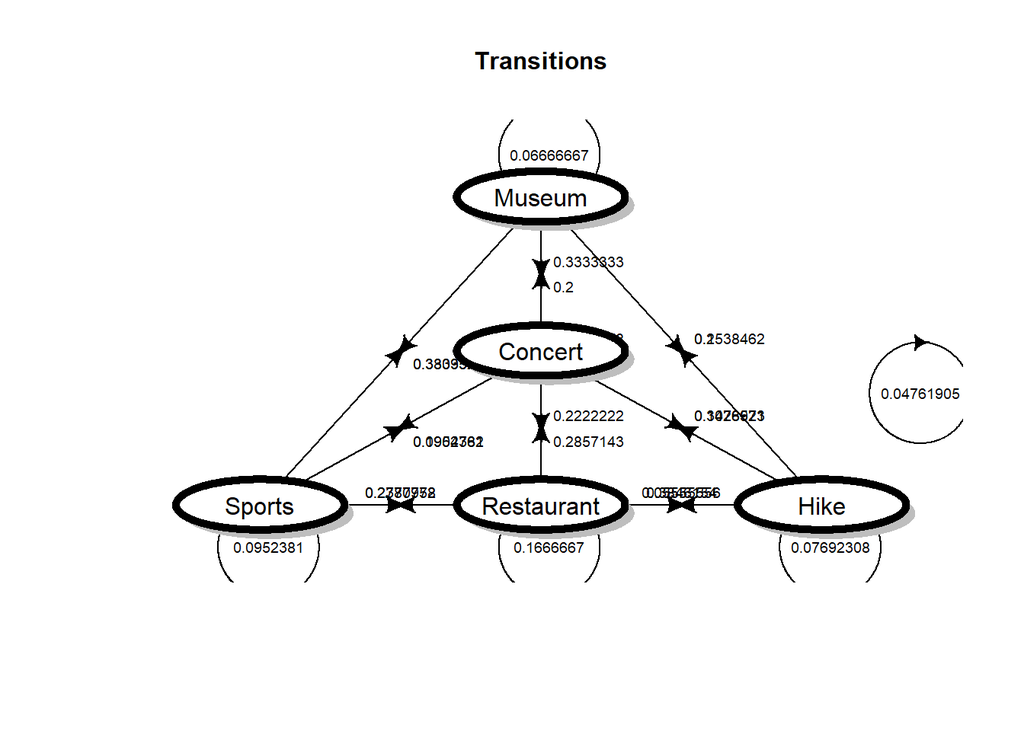

```r
pp <- plotmat(transMatrix, pos = c(1,1,3), curve = 0, name = headers,
              lwd = 1, box.lwd = 5, cex.txt = 0.6, self.cex = 0.6,
              self.shiftx = c(0.01, 0.45, 0.01, 0.01, 0.01),self.shifty = c(0.05, -0.05, -0.05, -0.05, -0.05),
              box.type = "circle", box.prop = 0.3, main = "Transitions")
```

## Calculate the Steady state Probabilities of the Markov chain

A steady-state behavior of a markov chain is the long-term probability that the system will be in each state. It is the number of transitions applied to the systems that has no impact on the state vector, ie the current behavior of the system will continue into the future.

```r
steadyStates(mark_tourist)
```

```
##         Museum   Concert    Sports Restaurant      Hike
## [1,] 0.2411704 0.1718348 0.2103267  0.2399771 0.1366909
```

## How Likey is a person to attend a concert, Go on a hike, then eat at a resturant?

```r
## First we need to find the probability of concert to hike
## then we need Hike to Resturant
## We can get this by multiplying it in my transition matrix

transMatrix[2, 5] * transMatrix[5,4] * 100
```

```
## [1] 5.494505
```

```r
#So pretty much a 5 percent chance to to go from concert to hike to resturant
```

## Find the Likelihood of visiting any of the locations as the fifth step

```r
#starting prob vector
spv <- c(0.2, 0.2, 0.2, 0.2, 0.2)

#Take the transmatrix to the 5th power
transProb = transMatrix %^% 5

#Sum Columns for the 5th step
sumTrans = colSums(transProb)

#now take Spv column * SumTrans Column
spvTrans = spv * sumTrans

#Probability of visting any of these locations as the 5th step shown below.
spvTrans * 100
```

```
##     Museum    Concert     Sports Restaurant       Hike
##   24.12609   17.17922   21.02655   24.00018   13.66796
```